# Reflection on Regression and Classification Models with Group Project Data

Author

Grace Sen

Published

July 29, 2026

# 1 Introduction

## 1.1 Project Overview

This project applies supervised machine learning techniques to predict whether a customer will convert in a digital marketing campaign. Using the Digital Marketing Campaign Dataset, the analysis follows the complete tidymodels workflow, including data preparation, model training, evaluation, and comparison. The goal is to identify the model that best predicts customer conversion and to understand which customer and campaign characteristics contribute most to conversion.

## 1.2 Analytics Objective

The analytics objective is to predict whether a customer will convert after being exposed to a digital marketing campaign. Accurate predictions can help marketers identify high-potential customers, improve campaign targeting, and allocate marketing resources more effectively.

## 1.3 Machine Learning Task

- **Learning type:** Supervised learning
- **Outcome variable:** `Conversion`
- **Feature variables:** Customer demographics, campaign characteristics, website engagement, email activity, purchase history, and advertising information
- **Machine learning category:** Classification
- **Selected codebook:** Module 5 – Classification Models

**Note**

Because the outcome variable, **Conversion**, has two possible values (0 = No, 1 = Yes), this project is a binary classification problem.

# 2 Data Preparation

## 2.1 Load Libraries

The analysis uses the **tidymodels** framework for machine learning, along with several supporting packages for data manipulation, visualization, and model interpretation.

```r
library(tidymodels)
library(tidyverse)
library(skimr)
library(kableExtra)
library(ranger)

tidymodels_prefer()
```

## 2.2 Load Dataset

The dataset contains customer demographics, campaign characteristics, online engagement, email activity, purchase history, and a binary conversion outcome.

```r
marketing <- read_csv("~/Documents/IBM6540/Group_Project/dataset/digital_marketing_campaign_dataset.csv")
```

## 2.3 Clean the Data

```r
marketing <- marketing %>%
  mutate(
    Conversion = factor(Conversion),
    Gender = factor(Gender),
    CampaignType = factor(CampaignType),
    CampaignChannel = factor(CampaignChannel),
    AdvertisingPlatform = factor(AdvertisingPlatform),
    AdvertisingTool = factor(AdvertisingTool)
  )

marketing <- marketing %>%
  select(-CustomerID)
```

## 2.4 Explore the Dataset

Before building any models, it is important to understand the structure of the dataset.

```r
glimpse(marketing)
```

```
Rows: 8,000
Columns: 19
$ Age                 <dbl> 56, 69, 46, 32, 60, 25, 38, 56, 36, 40, 28, 28, 41…
$ Gender              <fct> Female, Male, Female, Female, Female, Female, Fema…
$ Income              <dbl> 136912, 41760, 88456, 44085, 83964, 42925, 25615, …
$ CampaignChannel     <fct> Social Media, Email, PPC, PPC, PPC, Social Media, …
$ CampaignType        <fct> Awareness, Retention, Awareness, Conversion, Conve…
$ AdSpend             <dbl> 6497.8701, 3898.6686, 1546.4296, 539.5259, 1678.04…
$ ClickThroughRate    <dbl> 0.04391851, 0.15572507, 0.27749037, 0.13761125, 0.…
$ ConversionRate      <dbl> 0.08803141, 0.18272468, 0.07642272, 0.08800419, 0.…
$ WebsiteVisits       <dbl> 0, 42, 2, 47, 0, 6, 42, 48, 13, 22, 47, 16, 13, 8,…
$ PagesPerVisit       <dbl> 2.399017, 2.917138, 8.223619, 4.540939, 2.046847, …
$ TimeOnSite          <dbl> 7.396803, 5.352549, 13.794901, 14.688363, 13.99337…
$ SocialShares        <dbl> 19, 5, 0, 89, 6, 95, 54, 96, 73, 14, 94, 23, 28, 8…
$ EmailOpens          <dbl> 6, 2, 11, 2, 6, 5, 14, 9, 4, 8, 16, 18, 16, 8, 16,…
$ EmailClicks         <dbl> 9, 7, 2, 2, 6, 8, 3, 3, 8, 4, 5, 6, 5, 1, 8, 1, 8,…
$ PreviousPurchases   <dbl> 4, 2, 8, 0, 8, 0, 6, 0, 5, 8, 6, 5, 4, 2, 1, 1, 8,…
$ LoyaltyPoints       <dbl> 688, 3459, 2337, 2463, 4345, 3316, 930, 2983, 460,…
$ AdvertisingPlatform <fct> IsConfid, IsConfid, IsConfid, IsConfid, IsConfid, …
$ AdvertisingTool     <fct> ToolConfid, ToolConfid, ToolConfid, ToolConfid, To…
$ Conversion          <fct> 1, 1, 1, 1, 1, 1, 1, 1, 1, 1, 1, 1, 1, 1, 1, 0, 1,…
```

```r
summary(marketing)
```

```
      Age           Gender         Income           CampaignChannel
 Min.   :18.00   Female:4839   Min.   : 20014   Email       :1557
 1st Qu.:31.00   Male  :3161   1st Qu.: 51744   PPC         :1655
 Median :43.00                 Median : 84926   Referral    :1719
 Mean   :43.63                 Mean   : 84664   SEO         :1550
 3rd Qu.:56.00                 3rd Qu.:116816   Social Media:1519
 Max.   :69.00                 Max.   :149986
        CampaignType     AdSpend       ClickThroughRate  ConversionRate
 Awareness    :1988   Min.   : 100.1   Min.   :0.01000   Min.   :0.01002
 Consideration:1988   1st Qu.:2523.2   1st Qu.:0.08263   1st Qu.:0.05641
 Conversion   :2077   Median :5013.4   Median :0.15451   Median :0.10405
 Retention    :1947   Mean   :5000.9   Mean   :0.15483   Mean   :0.10439
                      3rd Qu.:7408.0   3rd Qu.:0.22821   3rd Qu.:0.15208
                      Max.   :9997.9   Max.   :0.29997   Max.   :0.19999
 WebsiteVisits   PagesPerVisit     TimeOnSite       SocialShares
 Min.   : 0.00   Min.   :1.000   Min.   : 0.5017   Min.   : 0.0
 1st Qu.:13.00   1st Qu.:3.302   1st Qu.: 4.0683   1st Qu.:25.0
 Median :25.00   Median :5.534   Median : 7.6830   Median :50.0
 Mean   :24.75   Mean   :5.549   Mean   : 7.7277   Mean   :49.8
 3rd Qu.:37.00   3rd Qu.:7.836   3rd Qu.:11.4815   3rd Qu.:75.0
 Max.   :49.00   Max.   :9.999   Max.   :14.9953   Max.   :99.0
   EmailOpens      EmailClicks    PreviousPurchases LoyaltyPoints
 Min.   : 0.000   Min.   :0.000   Min.   :0.000     Min.   :   0
 1st Qu.: 5.000   1st Qu.:2.000   1st Qu.:2.000     1st Qu.:1255
 Median : 9.000   Median :4.000   Median :4.000     Median :2497
 Mean   : 9.477   Mean   :4.467   Mean   :4.486     Mean   :2490
 3rd Qu.:14.000   3rd Qu.:7.000   3rd Qu.:7.000     3rd Qu.:3702
 Max.   :19.000   Max.   :9.000   Max.   :9.000     Max.   :4999
 AdvertisingPlatform   AdvertisingTool Conversion
 IsConfid:8000       ToolConfid:8000   0: 988
                                       1:7012
```

```r
skimr::skim(marketing)
```

Data summary

| Name | marketing |
| --- | --- |
| Number of rows | 8000 |
| Number of columns | 19 |
| _______________________ |  |
| Column type frequency: |  |
| factor | 6 |
| numeric | 13 |
| ________________________ |  |
| Group variables | None |

**Variable type: factor**

| skim_variable | n_missing | complete_rate | ordered | n_unique | top_counts |
| --- | --- | --- | --- | --- | --- |
| Gender | 0 | 1 | FALSE | 2 | Fem: 4839, Mal: 3161 |
| CampaignChannel | 0 | 1 | FALSE | 5 | Ref: 1719, PPC: 1655, Ema: 1557, SEO: 1550 |
| CampaignType | 0 | 1 | FALSE | 4 | Con: 2077, Awa: 1988, Con: 1988, Ret: 1947 |
| AdvertisingPlatform | 0 | 1 | FALSE | 1 | IsC: 8000 |
| AdvertisingTool | 0 | 1 | FALSE | 1 | Too: 8000 |
| Conversion | 0 | 1 | FALSE | 2 | 1: 7012, 0: 988 |

**Variable type: numeric**

| skim_variable | n_missing | complete_rate | mean | sd | p0 | p25 | p50 | p75 | p100 | hist |
| --- | --- | --- | --- | --- | --- | --- | --- | --- | --- | --- |
| Age | 0 | 1 | 43.63 | 14.90 | 18.00 | 31.00 | 43.00 | 56.00 | 69.00 | ▇▇▇▇▇ |
| Income | 0 | 1 | 84664.20 | 37580.39 | 20014.00 | 51744.50 | 84926.50 | 116815.75 | 149986.00 | ▇▇▇▇▇ |
| AdSpend | 0 | 1 | 5000.94 | 2838.04 | 100.05 | 2523.22 | 5013.44 | 7407.99 | 9997.91 | ▇▇▇▇▇ |
| ClickThroughRate | 0 | 1 | 0.15 | 0.08 | 0.01 | 0.08 | 0.15 | 0.23 | 0.30 | ▇▇▇▇▇ |
| ConversionRate | 0 | 1 | 0.10 | 0.05 | 0.01 | 0.06 | 0.10 | 0.15 | 0.20 | ▇▇▇▇▇ |
| WebsiteVisits | 0 | 1 | 24.75 | 14.31 | 0.00 | 13.00 | 25.00 | 37.00 | 49.00 | ▇▇▇▇▇ |
| PagesPerVisit | 0 | 1 | 5.55 | 2.61 | 1.00 | 3.30 | 5.53 | 7.84 | 10.00 | ▇▇▇▇▇ |
| TimeOnSite | 0 | 1 | 7.73 | 4.23 | 0.50 | 4.07 | 7.68 | 11.48 | 15.00 | ▇▇▇▇▇ |
| SocialShares | 0 | 1 | 49.80 | 28.90 | 0.00 | 25.00 | 50.00 | 75.00 | 99.00 | ▇▇▇▇▇ |
| EmailOpens | 0 | 1 | 9.48 | 5.71 | 0.00 | 5.00 | 9.00 | 14.00 | 19.00 | ▇▇▇▇▇ |
| EmailClicks | 0 | 1 | 4.47 | 2.86 | 0.00 | 2.00 | 4.00 | 7.00 | 9.00 | ▇▇▇▇▇ |
| PreviousPurchases | 0 | 1 | 4.49 | 2.89 | 0.00 | 2.00 | 4.00 | 7.00 | 9.00 | ▇▇▇▇▇ |
| LoyaltyPoints | 0 | 1 | 2490.27 | 1429.53 | 0.00 | 1254.75 | 2497.00 | 3702.25 | 4999.00 | ▇▇▇▇▇ |

## 2.5 Check Missing Values

The dataset should be checked for missing values before preprocessing.

```r
marketing %>%
  summarise(across(everything(), ~sum(is.na(.)))) %>%
  pivot_longer(everything(),
               names_to = "Variable",
               values_to = "Missing_Values") %>%
  filter(Missing_Values > 0)
```

| Variable | Missing_Values |
| --- | --- |

# 3 Machine Learning Workflow

## 3.1 Data Splitting

### 3.1.1 Split the Data into Training and Testing Sets

```r
set.seed(123)

marketing_split <- initial_split(
  marketing,
  prop = 0.8,
  strata = Conversion
)

marketing_train <- training(marketing_split)
marketing_test  <- testing(marketing_split)
```

### 3.1.2 Training and Testing Dataset Sizes

```r
tibble(
  Dataset = c("Training", "Testing"),
  Observations = c(
    nrow(marketing_train),
    nrow(marketing_test)
  )
)
```

| Dataset | Observations |
| --- | --- |
| Training | 6399 |
| Testing | 1601 |

### 3.1.3 Class Distribution in the Training Set

```r
marketing_train %>%
  count(Conversion) %>%
  mutate(
    Percent = scales::percent(n / sum(n))
  )
```

| Conversion | n | Percent |
| --- | --- | --- |
| 0 | 790 | 12% |
| 1 | 5609 | 88% |

### 3.1.4 Class Distribution in the Testing Set

```r
marketing_test %>%
  count(Conversion) %>%
  mutate(
    Percent = scales::percent(n / sum(n))
  )
```

| Conversion | n | Percent |
| --- | --- | --- |
| 0 | 198 | 12% |
| 1 | 1403 | 88% |

**Tip**

A stratified split preserves the proportion of converted and non-converted customers in both the training and testing datasets. This helps ensure that the model is trained and evaluated on data with similar class distributions.

## 3.2 Data Preprocessing

Before fitting the models, the predictor variables are preprocessed using a recipe. The recipe standardizes numeric variables, converts categorical variables into dummy variables, and removes any predictors with zero variance. These steps help prepare the data for machine learning while ensuring the same preprocessing is applied to both the training and testing datasets.

### 3.2.1 Create the Recipe

```r
marketing_recipe <-
  recipe(Conversion ~ ., data = marketing_train) %>%
  step_rm(AdvertisingPlatform, AdvertisingTool) %>%
  step_normalize(all_numeric_predictors()) %>%
  step_dummy(all_nominal_predictors()) %>%
  step_zv(all_predictors())
```

### 3.2.2 Prepare the Recipe

```r
marketing_prep <- prep(marketing_recipe)
```

### 3.2.3 Review the Recipe

```r
marketing_prep
```

[output not shown]

**NoteWhy use a recipe?**

A **recipe** creates a consistent preprocessing workflow for the data. In this project, it removes constant predictors, normalizes numeric variables, creates dummy variables for categorical predictors, and removes any zero-variance features. The recipe is **prepped** using only the training data and then automatically applied to both the training and testing datasets through the workflow, helping prevent data leakage.

# 4 Model 1: Logistic Regression

## 4.1 Why Logistic Regression?

Logistic regression was selected as the first machine learning model because the outcome variable, **Conversion**, is binary (0 = No, 1 = Yes). It estimates the probability that a customer will convert based on customer demographics, campaign characteristics, engagement behavior, and purchase history. In addition, logistic regression is easy to interpret and provides a strong baseline for comparing more complex models.

**Note**

Logistic regression is widely used for binary classification problems because it predicts probabilities between 0 and 1 while providing interpretable relationships between predictors and the outcome.

## 4.2 Model Specification

### 4.2.1 Specify the Logistic Regression Model

```r
log_spec <-
  logistic_reg() %>%
  set_engine("glm") %>%
  set_mode("classification")
```

### 4.2.2 Create the Workflow

```r
log_workflow <-
  workflow() %>%
  add_recipe(marketing_recipe) %>%
  add_model(log_spec)
```

### 4.2.3 Fit the Logistic Regression Model

```r
log_fit <-
  fit(
    log_workflow,
    data = marketing_train
  )
```

### 4.2.4 Review Model Coefficients

```r
tidy(extract_fit_parsnip(log_fit))
```

| term | estimate | std.error | statistic | p.value |
| --- | --- | --- | --- | --- |
| (Intercept) | 2.1827069 | 0.1245055 | 17.5310018 | 0.0000000 |
| Age | -0.0314569 | 0.0424535 | -0.7409735 | 0.4587095 |
| Income | 0.0438859 | 0.0424394 | 1.0340838 | 0.3010970 |
| AdSpend | 0.4553478 | 0.0439565 | 10.3590526 | 0.0000000 |
| ClickThroughRate | 0.4811384 | 0.0440729 | 10.9168667 | 0.0000000 |
| ConversionRate | 0.3323661 | 0.0435808 | 7.6264312 | 0.0000000 |
| WebsiteVisits | 0.3366043 | 0.0428466 | 7.8560361 | 0.0000000 |
| PagesPerVisit | 0.4144745 | 0.0436379 | 9.4980329 | 0.0000000 |
| TimeOnSite | 0.5059656 | 0.0445340 | 11.3613423 | 0.0000000 |
| SocialShares | -0.0589246 | 0.0426536 | -1.3814683 | 0.1671350 |
| EmailOpens | 0.4769420 | 0.0443471 | 10.7547456 | 0.0000000 |
| EmailClicks | 0.4982908 | 0.0449558 | 11.0840168 | 0.0000000 |
| PreviousPurchases | 0.4425846 | 0.0438541 | 10.0922034 | 0.0000000 |
| LoyaltyPoints | 0.3773793 | 0.0433805 | 8.6992841 | 0.0000000 |
| Gender_Male | 0.0630572 | 0.0871002 | 0.7239618 | 0.4690892 |
| CampaignChannel_PPC | 0.1462695 | 0.1334483 | 1.0960760 | 0.2730455 |
| CampaignChannel_Referral | 0.2122218 | 0.1326791 | 1.5995119 | 0.1097069 |
| CampaignChannel_SEO | 0.1245303 | 0.1346222 | 0.9250352 | 0.3549476 |
| CampaignChannel_Social.Media | -0.0084399 | 0.1350619 | -0.0624892 | 0.9501733 |
| CampaignType_Consideration | 0.1154289 | 0.1132966 | 1.0188205 | 0.3082882 |
| CampaignType_Conversion | 1.0900704 | 0.1354060 | 8.0503872 | 0.0000000 |
| CampaignType_Retention | 0.0476241 | 0.1125016 | 0.4233192 | 0.6720624 |

### 4.2.5 Interpretation

The logistic regression results show that several marketing engagement variables, including **AdSpend, ClickThroughRate, WebsiteVisits, TimeOnSite, EmailOpens, EmailClicks, PreviousPurchases, and LoyaltyPoints**, are significant predictors of customer conversion. Positive coefficients indicate a higher likelihood of conversion, while negative coefficients indicate a lower likelihood. Several demographic and campaign variables were not statistically significant, suggesting they have less influence on conversion in this model.

# 5 Model 2: Random Forest

## 5.1 Why Random Forest?

Random Forest was selected as an alternative machine learning model because it can capture complex and nonlinear relationships among variables. Unlike logistic regression, Random Forest combines predictions from many decision trees, which often improves predictive performance while reducing overfitting. Comparing Random Forest with Logistic Regression helps determine whether the added model complexity leads to better classification performance.

**Note**

Both models use the same training data and preprocessing recipe. This allows the comparison to focus on differences between the models rather than differences in data preparation.

## 5.2 Model Specification

### 5.2.1 Specify the Random Forest Model

```r
rf_spec <-
  rand_forest(
    trees = 500
  ) %>%
  set_engine(
    "ranger",
    importance = "impurity"
  ) %>%
  set_mode("classification")
```

### 5.2.2 Create the Workflow

```r
rf_workflow <-
  workflow() %>%
  add_recipe(marketing_recipe) %>%
  add_model(rf_spec)
```

### 5.2.3 Fit the Random Forest Model

```r
rf_fit <-
  fit(
    rf_workflow,
    data = marketing_train
  )
```

### 5.2.4 Review the Model

```r
rf_fit
```

```
══ Workflow [trained] ══════════════════════════════════════════════════════════
Preprocessor: Recipe
Model: rand_forest()

── Preprocessor ────────────────────────────────────────────────────────────────
4 Recipe Steps

• step_rm()
• step_normalize()
• step_dummy()
• step_zv()

── Model ───────────────────────────────────────────────────────────────────────
Ranger result

Call:
 ranger::ranger(x = maybe_data_frame(x), y = y, num.trees = ~500,      importance = ~"impurity", num.threads = 1, verbose = FALSE,      seed = sample.int(10^5, 1), probability = TRUE)

Type:                             Probability estimation
Number of trees:                  500
Sample size:                      6399
Number of independent variables:  21
Mtry:                             4
Target node size:                 10
Variable importance mode:         impurity
Splitrule:                        gini
OOB prediction error (Brier s.):  0.07868959
```

### 5.2.5 Interpretation

The Random Forest model was successfully trained using 500 decision trees. Each tree is built using a different random sample of the training data and a random subset of predictors. The final prediction is based on the combined predictions of all trees, which helps improve predictive performance while reducing the risk of overfitting.

# 6 Model Comparison

## 6.1 10-Fold Cross-Validation

To compare model performance fairly, both models were evaluated using 10-fold cross-validation. This approach repeatedly splits the training data into training and validation folds, providing a more reliable estimate of model performance than a single train/test split.

### 6.1.1 Create 10-Fold Cross-Validation

```r
set.seed(123)

marketing_folds <-
  vfold_cv(
    marketing_train,
    v = 10,
    strata = Conversion
  )
```

### 6.1.2 Cross-Validate Logistic Regression

```r
log_cv <-
  fit_resamples(
    log_workflow,
    resamples = marketing_folds,
    metrics = metric_set(
      accuracy,
      roc_auc,
      sens,
      spec
    )
  )
```

### 6.1.3 Cross-Validate Random Forest

```r
rf_cv <-
  fit_resamples(
    rf_workflow,
    resamples = marketing_folds,
    metrics = metric_set(
      accuracy,
      roc_auc,
      sens,
      spec
    )
  )
```

### 6.1.4 Logistic Regression Performance

```r
collect_metrics(log_cv)
```

| .metric | .estimator | mean | n | std_err | .config |
| --- | --- | --- | --- | --- | --- |
| accuracy | binary | 0.8937334 | 10 | 0.0015096 | pre0_mod0_post0 |
| roc_auc | binary | 0.8012821 | 10 | 0.0103597 | pre0_mod0_post0 |
| sens | binary | 0.2177215 | 10 | 0.0106409 | pre0_mod0_post0 |
| spec | binary | 0.9889464 | 10 | 0.0014505 | pre0_mod0_post0 |

### 6.1.5 Random Forest Performance

```r
collect_metrics(rf_cv)
```

| .metric | .estimator | mean | n | std_err | .config |
| --- | --- | --- | --- | --- | --- |
| accuracy | binary | 0.8924839 | 10 | 0.0020375 | pre0_mod0_post0 |
| roc_auc | binary | 0.8247080 | 10 | 0.0097287 | pre0_mod0_post0 |
| sens | binary | 0.1367089 | 10 | 0.0147136 | pre0_mod0_post0 |
| spec | binary | 0.9989305 | 10 | 0.0005446 | pre0_mod0_post0 |

### 6.1.6 Compare Model Performance

```r
bind_rows(
  collect_metrics(log_cv) %>%
    mutate(Model = "Logistic Regression"),
  collect_metrics(rf_cv) %>%
    mutate(Model = "Random Forest")
) %>%
  select(Model, .metric, mean, std_err)
```

| Model | .metric | mean | std_err |
| --- | --- | --- | --- |
| Logistic Regression | accuracy | 0.8937334 | 0.0015096 |
| Logistic Regression | roc_auc | 0.8012821 | 0.0103597 |
| Logistic Regression | sens | 0.2177215 | 0.0106409 |
| Logistic Regression | spec | 0.9889464 | 0.0014505 |
| Random Forest | accuracy | 0.8924839 | 0.0020375 |
| Random Forest | roc_auc | 0.8247080 | 0.0097287 |
| Random Forest | sens | 0.1367089 | 0.0147136 |
| Random Forest | spec | 0.9989305 | 0.0005446 |

## 6.2 Interpretation

Overall, **Random Forest** was selected as the better model because ROC AUC is a more informative metric for an imbalanced classification problem like customer conversion. Its higher ROC AUC suggests that it has stronger overall classification performance and is more likely to generalize well to new customer data.

**Note**

Although Logistic Regression achieved slightly higher accuracy, **ROC AUC** was used as the primary metric because the dataset is imbalanced. ROC AUC evaluates the model across all classification thresholds and provides a more reliable measure of overall performance.

# 7 Feature Importance

## 7.1 Variable Importance

Feature importance was extracted from the Random Forest model using the impurity importance scores provided by the `ranger` engine. Variables with higher importance values contribute more to predicting customer conversion.

### 7.1.1 Extract Variable Importance

```r
rf_importance <-
  tibble(
    Variable = names(extract_fit_engine(rf_fit)$variable.importance),
    Importance = extract_fit_engine(rf_fit)$variable.importance
  ) %>%
  arrange(desc(Importance))

rf_importance
```

| Variable | Importance |
| --- | --- |
| PagesPerVisit | 107.187189 |
| TimeOnSite | 100.525870 |
| ClickThroughRate | 94.962878 |
| AdSpend | 94.933915 |
| ConversionRate | 91.749415 |
| LoyaltyPoints | 90.430930 |
| WebsiteVisits | 74.411859 |
| PreviousPurchases | 69.009274 |
| EmailOpens | 68.678920 |
| Income | 60.660062 |
| EmailClicks | 59.241902 |
| SocialShares | 50.334686 |
| Age | 48.040056 |
| CampaignType_Conversion | 17.344641 |
| CampaignType_Retention | 7.181670 |
| CampaignType_Consideration | 6.653195 |
| CampaignChannel_Social.Media | 6.572058 |
| Gender_Male | 6.066948 |
| CampaignChannel_PPC | 5.684854 |
| CampaignChannel_SEO | 5.543286 |
| CampaignChannel_Referral | 5.529229 |

### 7.1.2 Plot Feature Importance

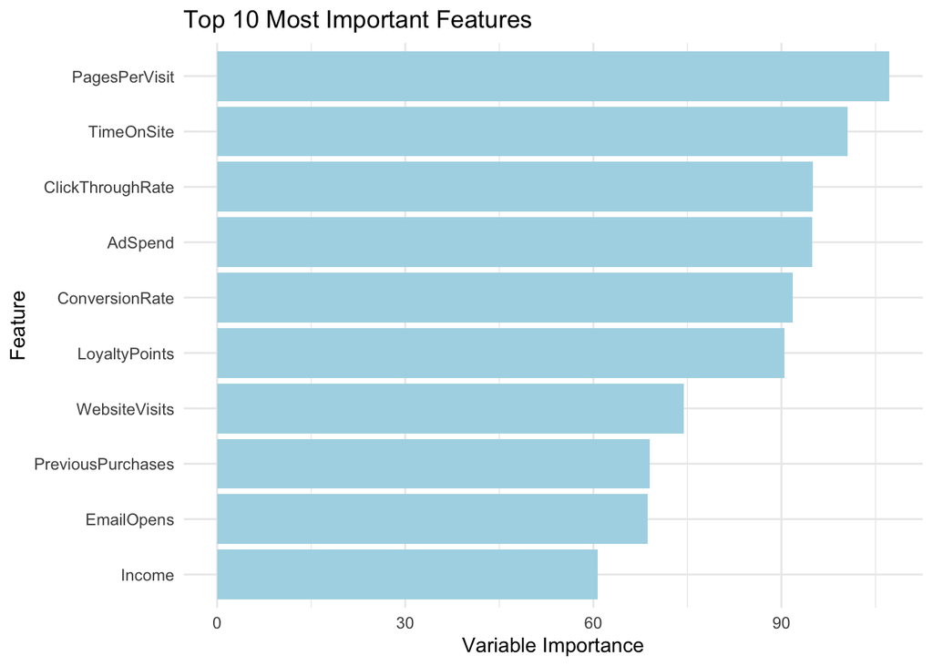

```r
rf_importance %>%
  slice_max(Importance, n = 10) %>%
  ggplot(aes(
    x = reorder(Variable, Importance),
    y = Importance
  )) +
  geom_col(fill = "lightblue") +
  coord_flip() +
  labs(
    title = "Top 10 Most Important Features",
    x = "Feature",
    y = "Variable Importance"
  ) +
  theme_minimal()
```

## 7.2 Interpretation

The feature importance results indicate that **PagesPerVisit**, **TimeOnSite**, **AdSpend**, and **ClickThroughRate** are the strongest predictors of customer conversion. Customer engagement variables, such as website visits, email opens, email clicks, previous purchases, and loyalty points, also rank highly, suggesting that customers who interact more with marketing campaigns are more likely to convert.

Overall, the results are reasonable because customer engagement and campaign performance are expected to have a stronger influence on conversion than demographic characteristics alone. These findings suggest that marketers should focus on increasing customer engagement and optimizing campaign performance to improve conversion rates.

**Note**

The Random Forest model identifies which variables contribute most to prediction accuracy, but feature importance does not indicate whether a variable has a positive or negative effect on conversion. Logistic Regression coefficients are better suited for interpreting the direction of each relationship.

# 8 Reflection

## 8.1 Why was Logistic Regression a good baseline?

Logistic Regression was a good baseline because it is simple, easy to interpret, and well suited for binary classification problems like predicting customer conversion. It also helped identify which customer and marketing variables were significantly associated with conversion, making it a useful benchmark for comparing more complex models.

## 8.2 Why did Random Forest perform differently?

Random Forest achieved a higher ROC AUC because it can capture complex relationships and interactions between variables that Logistic Regression may not detect. Although Logistic Regression had slightly higher accuracy and sensitivity, Random Forest provided better overall classification performance, making it the stronger model for this dataset.

## 8.3 Limitations

One limitation of this analysis is that it only used the variables available in the dataset. Customer conversion may also be influenced by factors such as customer preferences, seasonality, or previous campaign history, which were not included. In addition, feature importance from Random Forest shows which variables are important but does not explain the direction of their effects.

## 8.4 Future Work

Future work could focus on tuning the Random Forest hyperparameters to improve model performance. Additional machine learning models, such as XGBoost or LightGBM, could also be evaluated and compared using cross-validation. Incorporating more customer behavior and marketing variables may further improve prediction accuracy.

# 9 Conclusion

This project developed and compared two classification models, Logistic Regression and Random Forest, to predict customer conversion using a digital marketing campaign dataset. Both models achieved strong overall performance, with Random Forest producing the highest ROC AUC and providing valuable insights into the factors that influence customer conversion.

The feature importance analysis showed that customer engagement variables, such as pages per visit, time on site, ad spend, and click-through rate, were the most influential predictors of conversion. These findings suggest that improving customer engagement and optimizing marketing campaigns can help increase conversion rates. Overall, this project demonstrates how machine learning can support marketing decision-making by providing accurate predictions and actionable business insights.

# 10 Appendix

## 10.1 GitHub Repository

https://github.com/gracesen/IBM-6540-GP-M08

## 10.2 GitHub Pages

https://gracesen.github.io/IBM-6540-GP-M08/